# Introduction to tidyverse

Rakesh Poduval, 2020-09-04

# Specification

The tidyverse is an opinionated collection of R packages designed for data science. All packages share an underlying design philosophy, grammar, and data structures.

Install the complete tidyverse with: `install.packages('tidyverse')`

For online documentation refer : `browseVignettes(package = "tidyverse")`

Book for reference : [R for Data Science by Hadley Wickham](https://r4ds.had.co.nz)

The book is really good and is recommended strongly.

# Examples

The package is extremely powerful and easy to work with. Lets take the so called `iris` data for this. Hadley uses `%>%` which he calls *pipes* to perform `tidyverse` operations. You can use the keyboard shortcut `ctrl + shift + M` for the pipe.

## Data manupulation

Lets start with simple operations like sorting the data.

```r
## order with respect to a column, by default it is in ascending order
iris %>% arrange(Sepal.Length) %>% head(5)
```

```
##   Sepal.Length Sepal.Width Petal.Length Petal.Width Species
## 1          4.3         3.0          1.1         0.1  setosa
## 2          4.4         2.9          1.4         0.2  setosa
## 3          4.4         3.0          1.3         0.2  setosa
## 4          4.4         3.2          1.3         0.2  setosa
## 5          4.5         2.3          1.3         0.3  setosa
```

```r
iris %>% arrange(desc(Sepal.Length)) %>% head(5)
```

```
##   Sepal.Length Sepal.Width Petal.Length Petal.Width   Species
## 1          7.9         3.8          6.4         2.0 virginica
## 2          7.7         3.8          6.7         2.2 virginica
## 3          7.7         2.6          6.9         2.3 virginica
## 4          7.7         2.8          6.7         2.0 virginica
## 5          7.7         3.0          6.1         2.3 virginica
```

Renaming existing columns.

```r
## renaming column name
iris %>% rename(sepalWidth = Sepal.Width) %>% head(3)
```

```
##   Sepal.Length sepalWidth Petal.Length Petal.Width Species
## 1          5.1        3.5          1.4         0.2  setosa
## 2          4.9        3.0          1.4         0.2  setosa
## 3          4.7        3.2          1.3         0.2  setosa
```

The select can be used in many ways based on the requirement. Please go through the online reference for more details.

```r
## selecting columns from a data. This also can be used for renaming
iris %>%
  select(sepalWidth = Sepal.Width, Petal.Width) %>%
  head(3)
```

```
##   sepalWidth Petal.Width
## 1        3.5         0.2
## 2        3.0         0.2
## 3        3.2         0.2
```

Adding a new column can be dine in multiple ways. `mutate()` is useful to add new columns that are functions of existing columns. `transmute()` eliminates all other columns not mentioned in it.

```r
# transform adds a new column
iris %>%
  transform(ratio = Sepal.Length/Sepal.Width) %>%
  head(3)
```

```
##   Sepal.Length Sepal.Width Petal.Length Petal.Width Species    ratio
## 1          5.1         3.5          1.4         0.2  setosa 1.457143
## 2          4.9         3.0          1.4         0.2  setosa 1.633333
## 3          4.7         3.2          1.3         0.2  setosa 1.468750
```

```r
# mutate adds new columns that are functions of existing columns
iris %>%
  mutate(ratio = Sepal.Length/Sepal.Width,
         adjusted = ratio * Petal.Length) %>%
  head(3)
```

```
##   Sepal.Length Sepal.Width Petal.Length Petal.Width Species    ratio adjusted
## 1          5.1         3.5          1.4         0.2  setosa 1.457143 2.040000
## 2          4.9         3.0          1.4         0.2  setosa 1.633333 2.286667
## 3          4.7         3.2          1.3         0.2  setosa 1.468750 1.909375
```

```r
# transmute eliminates rest of the columns
iris %>%
  transmute(ratio = Sepal.Length/Sepal.Width) %>%
  head(3)
```

```
##      ratio
## 1 1.457143
## 2 1.633333
## 3 1.468750
```

To subset a data use the `filter()` command

```r
iris %>%
  filter(Sepal.Length >= 5, Sepal.Width <= 6) %>%
  head(5)
```

```
##   Sepal.Length Sepal.Width Petal.Length Petal.Width Species
## 1          5.1         3.5          1.4         0.2  setosa
## 2          5.0         3.6          1.4         0.2  setosa
## 3          5.4         3.9          1.7         0.4  setosa
## 4          5.0         3.4          1.5         0.2  setosa
## 5          5.4         3.7          1.5         0.2  setosa
```

The group by is one of my favourite feature.

```r
# descriptives of single variable
iris %>%
  group_by(Species) %>%
  summarise(N = n(),
            mean = mean(Sepal.Length),
            median = median(Sepal.Length))
```

```
## # A tibble: 3 x 4
##   Species        N  mean median
##   <fct>      <int> <dbl>  <dbl>
## 1 setosa        50  5.01    5
## 2 versicolor    50  5.94    5.9
## 3 virginica     50  6.59    6.5
```

```r
# descriptive of all variables
iris %>%
  group_by(Species) %>%
  summarise_all(c('mean'))
```

```
## # A tibble: 3 x 5
##   Species    Sepal.Length Sepal.Width Petal.Length Petal.Width
##   <fct>             <dbl>       <dbl>        <dbl>       <dbl>
## 1 setosa             5.01        3.43         1.46       0.246
## 2 versicolor         5.94        2.77         4.26       1.33
## 3 virginica          6.59        2.97         5.55       2.03
```

```r
# iris %>% group_by(Species) %>% summarise_all(c('mean', 'median'))
```

Reshaping is widely used in our day to day operations

```r
# long data
iris %>% gather(variable, value, -Species) %>% head(5)
```

```
##   Species     variable value
## 1  setosa Sepal.Length   5.1
## 2  setosa Sepal.Length   4.9
## 3  setosa Sepal.Length   4.7
## 4  setosa Sepal.Length   4.6
## 5  setosa Sepal.Length   5.0
```

```r
# wide data
```

[output not shown]

we can even see add graphs at the end of any pipe operation

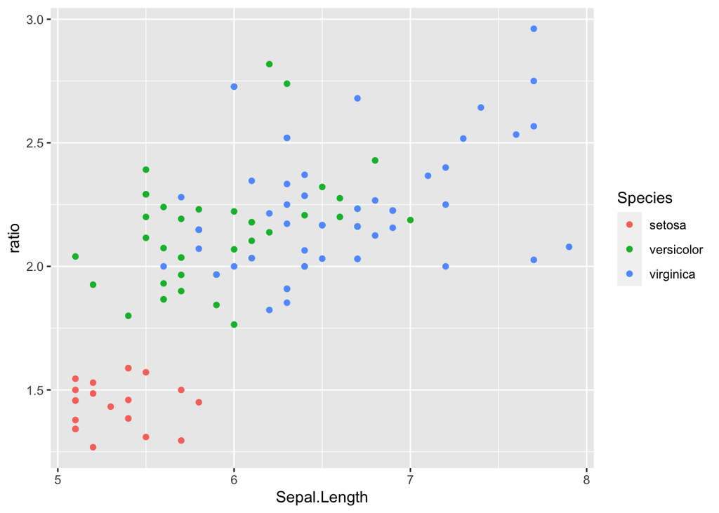

```r
iris %>%
  filter(Sepal.Length > 5) %>%
  mutate(ratio = Sepal.Length/Sepal.Width) %>%
  ggplot(aes(Sepal.Length, ratio)) +
  geom_point(aes(color = Species))
```

## Linear modelling

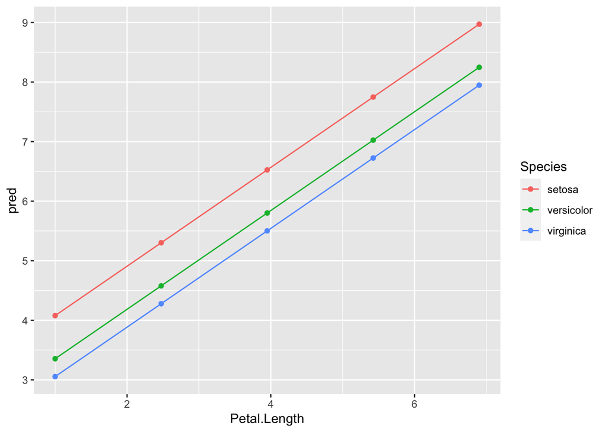

```r
library(modelr)

fit <- lm(Sepal.Length ~ . , data = iris)

data_grid(iris,
          Species,
          Petal.Length = seq_range(Petal.Length, n = 5),
          .model = fit) %>%
  add_predictions(fit, var = "pred") %>%
  ggplot(aes_string("Petal.Length", "pred", color = "Species")) +
  geom_line() +
  geom_point()
```

# Conclusion

This helps in narrating the complete story of the operations one is performing with the data and also add some interesting results at the end.